# signeR

#### *Rodrigo Drummond, Renan Valieris, Rafael Rosales and Israel Tojal da Silva*

## 1: Introduction

Motivation: Cancer is an evolutionary process driven by continuous acquisition of genetic variations in individual cells. The diversity and complexity of somatic mutational processes is a conspicuous feature orchestrated by DNA damage agents and repair processes, including exogenous or endogenous mutagen exposures, defects in DNA mismatch repair and enzymatic modification of DNA. The identification of the underlying mutational processes is central to understanding of cancer origin and evolution.

The **signeR** package focuses on the estimation and further analysis of mutational signatures. The functionalities of this package can be divided into three categories. First, it provides tools to process VCF files and generate matrices of SNV mutation counts and mutational opportunities, both defined according to a 3bp context (mutation site and its neighbouring 3' and 5' bases). Second, these count matrices are considered as input for the estimation of the underlying mutational signatures and the number of active mutational processes. Third, the package provides tools to correlate the activities of those signatures with other relevant information such as clinical data, in order to draw conclusions about the analysed genome samples, which can be useful for clinical applications. These include the Differential Exposure Score and the a posteriori sample classification.

Although signeR is intended for the estimation of mutational signatures, it actually provides a full Bayesian treatment to the non-negative matrix factorisation (NMF) model. Further details about the method can be found in Rosales & Drummond *et al.*, 2016 (see section 9.1 below).

This vignette briefly explains the use of **signeR** through examples.

## 2: Installation

Before installing, please make sure you have the latest version of R and [Bioconductor](http://bioconductor.org/) installed.

To install **signeR**, start R and enter:

```r
install.packages("BiocManager")
BiocManager::install("signeR")
```

For more information, see [this page](http://bioconductor.org/packages/signeR).

Once installed the library can be loaded as

```r
library(signeR)
```

OS X users might experience compilation errors due to missing gfortran libraries. Please read this section.

## 3: Preparing the input

**signeR** takes as input a count matrix of samples x features. Each feature is usually a SNV mutation within a 3bp context (96 features, 6 types of SNV mutations and 4 possibilities for the bases at each side of the SNV change). Optionally, an opportunity matrix can also be provided containing the count frequency of the features in the whole analyzed region for each sample. Although not required, this argument is highly recommended because it allows **signeR** to normalize the features frequency over the analyzed region.

Input matrices can be read both from a VCF or a tab-delimited files, as described next.

### 3.1: Input from VCF

The [VCF](http://www.1000genomes.org/wiki/Analysis/vcf4.0) file format is the most common format for storing genetic variations, the **signeR** package includes a utility function for generating a count matrix from the VCF:

```r
library(VariantAnnotation)

# BSgenome, equivalent to the one used on the variant call
library(BSgenome.Hsapiens.UCSC.hg19)

vcfobj <- readVcf("/path/to/a/file.vcf", "hg19")
mut <- genCountMatrixFromVcf(BSgenome.Hsapiens.UCSC.hg19, vcfobj)
```

This function will generate a matrix of mutation counts for each sample in the provided VCF.

If you have one vcf per sample you can combine the results into a single matrix like this:

```r
mut = matrix(ncol=96,nrow=0)
for(i in vcf_files) {
    vo = readVcf(i, "hg19")
    # sample name (should pick up from the vcf automatically if available)
    # colnames(vo) = i
    m0 = genCountMatrixFromVcf(mygenome, vo)
    mut = rbind(mut, m0)
}
dim(mut) # matrix with all samples
```

The opportunity matrix can also be generated from the reference genome (hg19 in the following case):

```r
library(rtracklayer)

target_regions <- import(con="/path/to/a/target.bed", format="bed")
opp <- genOpportunityFromGenome(BSgenome.Hsapiens.UCSC.hg19,
    target_regions, nsamples=nrow(mut))
```

Where `target.bed` is a [bed file](https://genome.ucsc.edu/FAQ/FAQformat.html#format1) containing the genomic regions analyzed by the variant caller.

If a BSgenome is not available for your genome, you can use a fasta file:

```r
library(Rsamtools)

# make sure /path/to/genome.fasta.fai exists !
# you can use "samtools faidx" command to create it
mygenome <- FaFile("/path/to/genome.fasta")

mut <- genCountMatrixFromVcf(mygenome, vcfobj)
opp <- genOpportunityFromGenome(mygenome, target_regions)
```

### 3.2: Input from tab-delimited file

By convention, the input file should be tab-delimited with sample names as row names and features as column names. Features should be refered in the format "base change:triplet", e.g. "C>A:TCG", as can be seen in the example below. Similarly, the opportunity matrix can be provided in a tab-delimited file with the same structure as the mutation counts file. An example of the required matrix format can be seen [here](https://github.com/TojalLab/signeR/blob/devel/inst/extdata/21_breast_cancers.mutations.txt).

This tutorial uses as input the 21 breast cancer dataset described in [Nik-Zainal et al 2012](http://dx.doi.org/10.1016/j.cell.2012.04.023). For the sake of convenience this dataset is included with the package and can be accessed by using the `system.file` function:

```r
mut <- read.table(system.file("extdata","21_breast_cancers.mutations.txt",
    package="signeR"), header=TRUE, check.names=FALSE)
opp <- read.table(system.file("extdata","21_breast_cancers.opportunity.txt",
    package="signeR"))
```

### 3.3: Known signatures

signeR analysis can incorporate any previous knowledge about the signatures present in the dataset. If signatures are known in advance, they can be provided as a matrix, which may be used by signeR in two different ways: a starting value that will be updated according to mutation patterns found on present data or a fixed set of parameters, kept unchanged during the estimation of exposures.

Signatures matrix shall contain each signature in one colum. An example of the required matrix format can be seen [here](https://github.com/TojalLab/signeR/blob/devel/inst/extdata/21_breast_cancers.mutations.txt).

Along this tutorial a matrix of signatures found in breast cancer, as described in [Cosmic database](https://cancer.sanger.ac.uk/cosmic/signatures_v2). For the sake of convenience this matrix is included with the package and can be accessed by the `system.file` function:

```r
Pmatrix <- as.matrix(read.table(system.file("extdata","Cosmic_signatures_BRC.txt",
    package="signeR"), sep="\t", check.names=FALSE))
```

## 4: Estimating the number of mutational processes and their signatures

**signeR** takes a count matrix as its only required parameter, but the user can provide an opportunity matrix as well. The algorithm allows the assessment of the number of signatures by three options, as follows.

1. signeR detects the number of signatures at run time by considering the best NMF factorisation rank between 1 and min(G, K)-1, with G = number of genomes and K = number of features (i.e. 96):

   ```r
   signatures <- signeR(M=mut, Opport=opp)
   ```

2. The user can give an interval of the possible numbers of signatures as the parameter nlim. **signeR** will calculate the optimal number of signatures within this range, for example:

   ```r
   signatures <- signeR(M=mut, Opport=opp, nlim=c(3,7))
   ```

   ```r
   signatures <- signeR(M=mut, Opport=opp, nsig=3, main_eval=100, EM_eval=50, EMit_lim=20)
   ```

4. Finally, when signatures are known in advance, **signeR** can use them as a starting point for the estimation of signatures in the present dataset. To this end, signatures must be provided in a matrix, as described in item 3.3 above. For example, the following command will make **signeR** use six Cosmic signatures found on breast cancer as a starting point:

   ```r
   signatures.Pstart <- signeR(M=mut, Opport=opp, P=Pmatrix, fixedP=FALSE, main_eval=100, EM_eval=50, EMit_lim=20)
   ```

The parameters `testing_burn` and `testing_eval` control the number of iterations used to estimate the number of signatures (default value is 1000 for both parameters). There are other arguments that may be passed on to signeR. Please have a look at signeR's manual, issued by typing `help(signeR)`.

Whenever **signeR** is left to decide which number of signatures is optimal, it will search for the rank Nsig that maximizes the median Bayesian Information Criterion (BIC). After the processing is done, this information can be plotted by the following command:

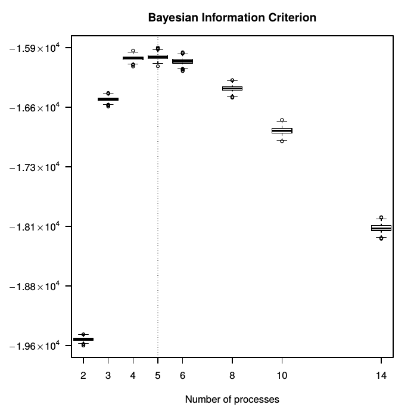

```r
BICboxplot(signatures)
```

Boxplot of BIC values, showing that the optimal number of signatures for this dataset is 5.

## 5: Estimating exposures to known signatures.

**signeR** also offer the possibility to estimate exposures to known signatures as, for example, the ones described on [Cosmic database](https://cancer.sanger.ac.uk/cosmic/signatures_v2). In this case, signatures should be provided in a matrix, as described in intem 3.3 above, and should be kept constant during analysis:

```r
Pmatrix <- as.matrix(read.table(system.file("extdata","Cosmic_signatures_BRC.txt",
    package="signeR"), sep="\t", check.names=FALSE))
```

The following command will make **signeR** estimate the exposures to the Cosmic signatures found on breast cancer:

```r
exposures.known.sigs <- signeR(M=mut, Opport=opp, P=Pmatrix, fixedP=TRUE, main_eval=100, EM_eval=50, EMit_lim=20)
```

Exposures can then be recovered from the signer output by the following command (as in any signer analysis):

```r
exposures <- Median_exp(exposures.known.sigs$SignExposures)
```

## 6: Results and plots

**signeR** offer several plots to visualize estimated signatures and their exposures, as weel as the convergence of the MCMC used to estimate them.

### 6.1: Plot the MCMC paths for the NMF parameters (P and E matrices)

The following instruction plots the MCMC samples paths for each entry of the signature matrix P and their exposures, i.e. the E matrix. Only post-burnin paths are available for plotting. Those plots are useful for checking if entries have leveled off, reflecting the sampler convergence.

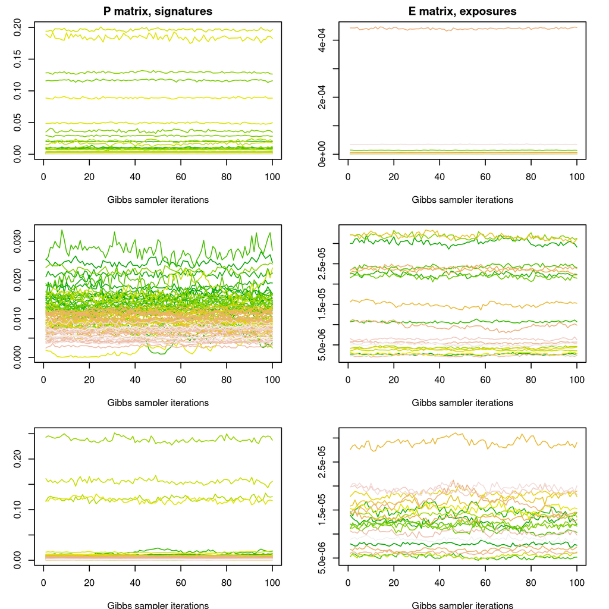

```r
Paths(signatures$SignExposures)
```

Each plot shows the entries and exposures of one signature along sampler iterations.

### 6.2: Plot the signatures

Once the processing is done, the estimated signatures can be displayed in two charts, described below.

#### Signature barplot

Signatures can be visualized in a barplot by issuing the following command:

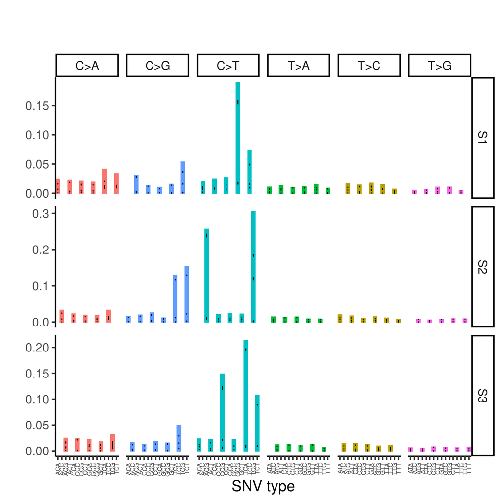

```r
SignPlot(signatures$SignExposures)
```

Signatures barplot with error bars reflecting the sample percentiles 0.05, 0.25, 0.75, and 0.95 for each entry.

#### Signature heatmap

Estimated signatures can also be visualized in a heatmap, generated by the following command:

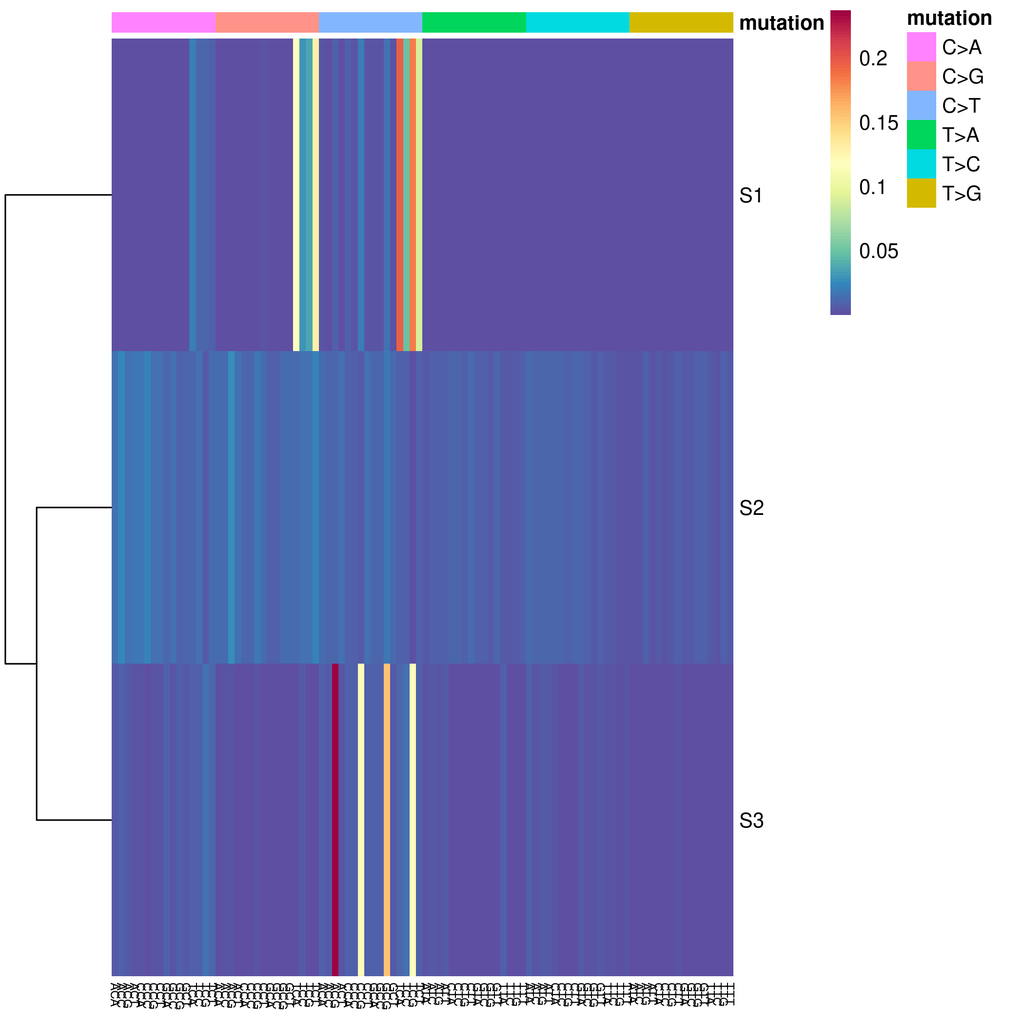

```r
SignHeat(signatures$SignExposures)
```

Heatmap showing the entries of each signature.

### 6.3: Plot the exposures

The relative contribution of each signature to the inspected genomes can be displayed in several ways. **signeR** currently provides three alternatives.

#### Exposure boxplot

The levels of exposure to each signature in all genome samples can also be plotted:

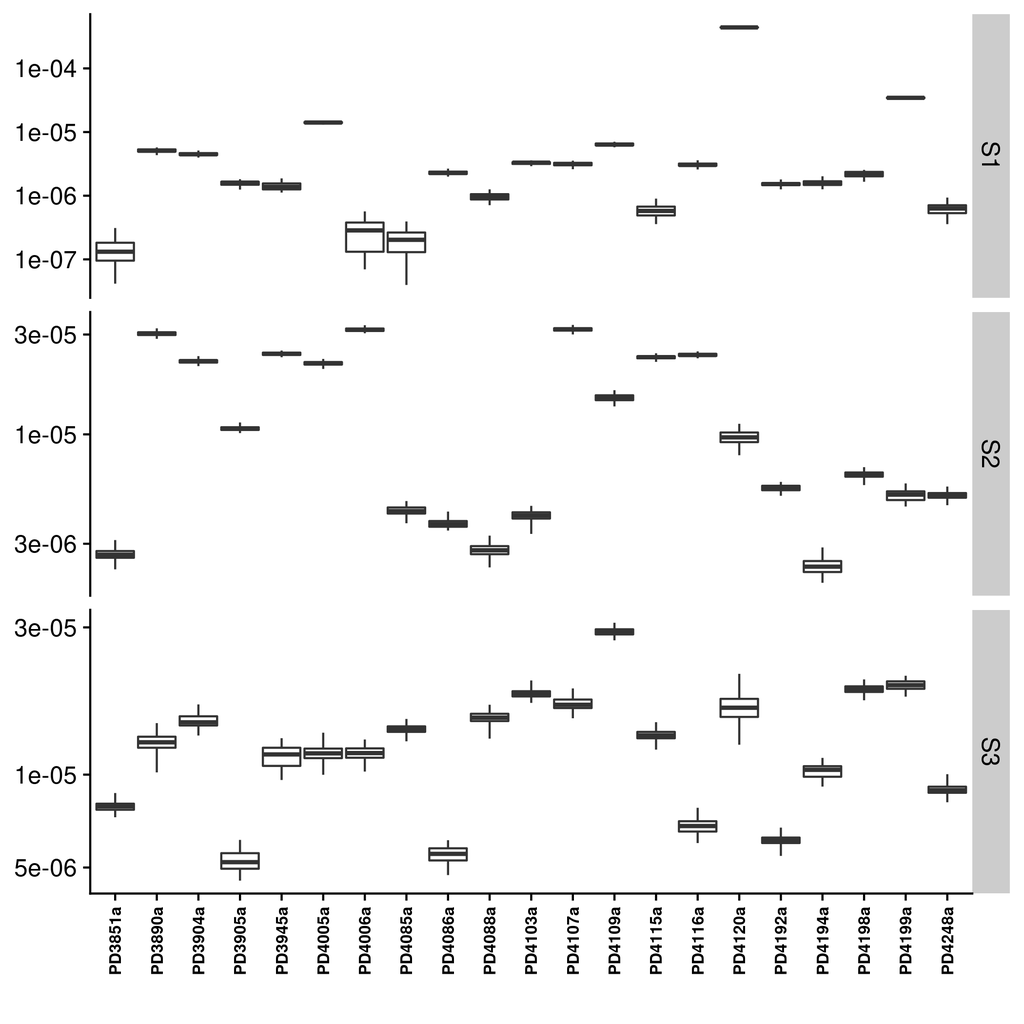

```r
ExposureBoxplot(signatures$SignExposures)
```

#### Exposure barplot

The contribution of the signatures to the mutations found on each genome sample can also be visualized in a barplot, plotted by the following command:

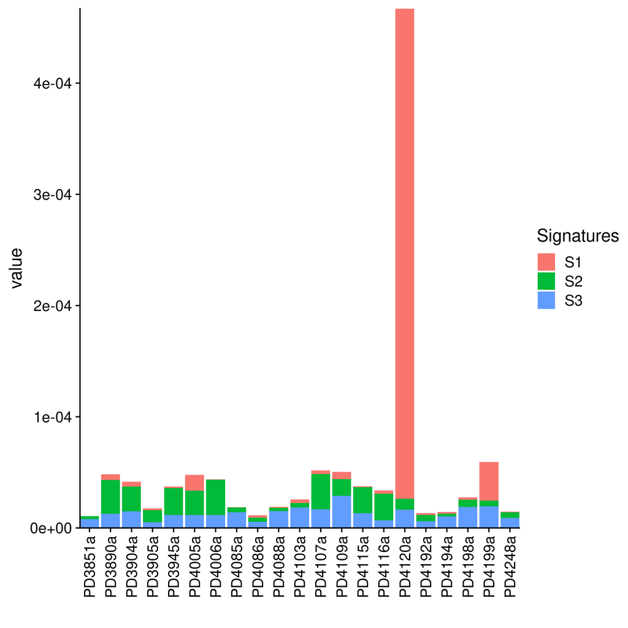

```r
ExposureBarplot(signatures$SignExposures)
```

Barplot showing the contributions of the signatures to genome samples mutation counts.

The **relative** contribution of signatures on each genome sample can also be visualized in a barplot, setting the **relative** parameter to TRUE:

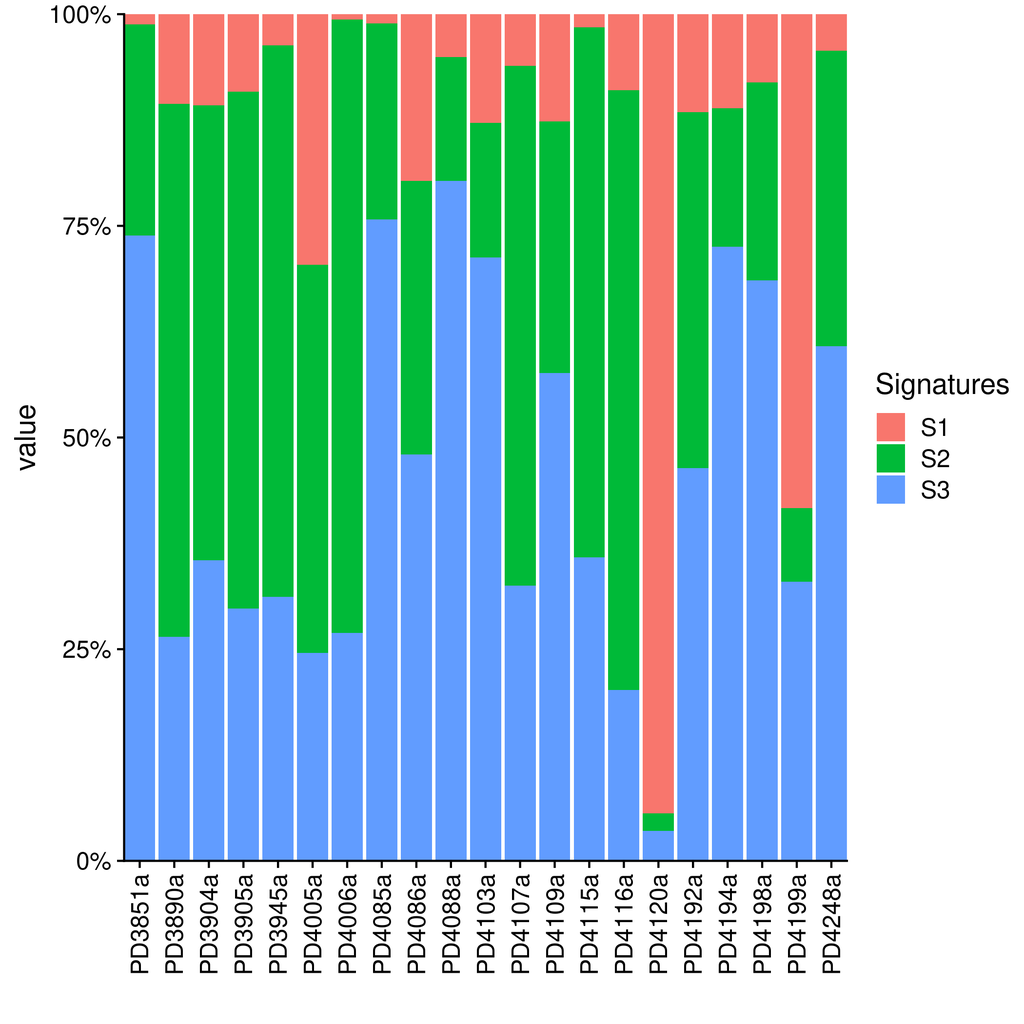

```r
ExposureBarplot(signatures$SignExposures, relative=TRUE)
```

Barplot showing the relative contributions of signatures to genome samples.

#### Exposure heatmap

The levels of exposure to each signature can also be plotted in a heatmap:

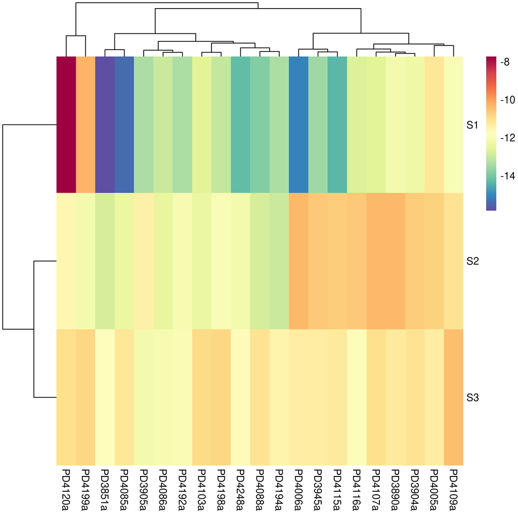

```r
ExposureHeat(signatures$SignExposures)
```

## 7: Supervised approaches to exposure analysis

If additional information is available for the samples analysed **signeR** is able to evaluate how those relate with the estimated exposures to mutational signatures. When additional data is categorical, differences in exposures among groups can be analysed and if some of the samples are unlabeled they can be labeled based on the similarity of their exposure profiles to those of labeled samples. In the case of a continuous additional feature, its correlation to estimated exposures can be evaluated. Survival data can also be analysed and the relation of signatures to survival can be accessed. In every case, analyses are repeated for all samples of the exposure matrix generated by **signeR** sampler and results are considered significant if they are consistently found on most of them.

### 7.1: Differential Exposure Analysis

**signeR** can highlight signatures that are differentially active among previously defined groups of samples. To perform this task **signeR** needs a vector of group labels. In this example the samples were divided according to germline mutations at BRCA genes: groups `wt`, `BRCA1+` and `BRCA2+`, taken from the description of the 21 breast cancer data set.

```r
# group labels, respective to each row of the mutation count matrix
BRCA_labels <- c("wt","BRCA1+","BRCA2+","BRCA1+","BRCA2+","BRCA1+","BRCA1+",
    "wt","wt","wt","wt","BRCA1+","wt","BRCA2+","BRCA2+","wt","wt","wt",
    "wt","wt","wt")

diff_exposure <- DiffExp(signatures$SignExposures, labels=BRCA_labels)
```

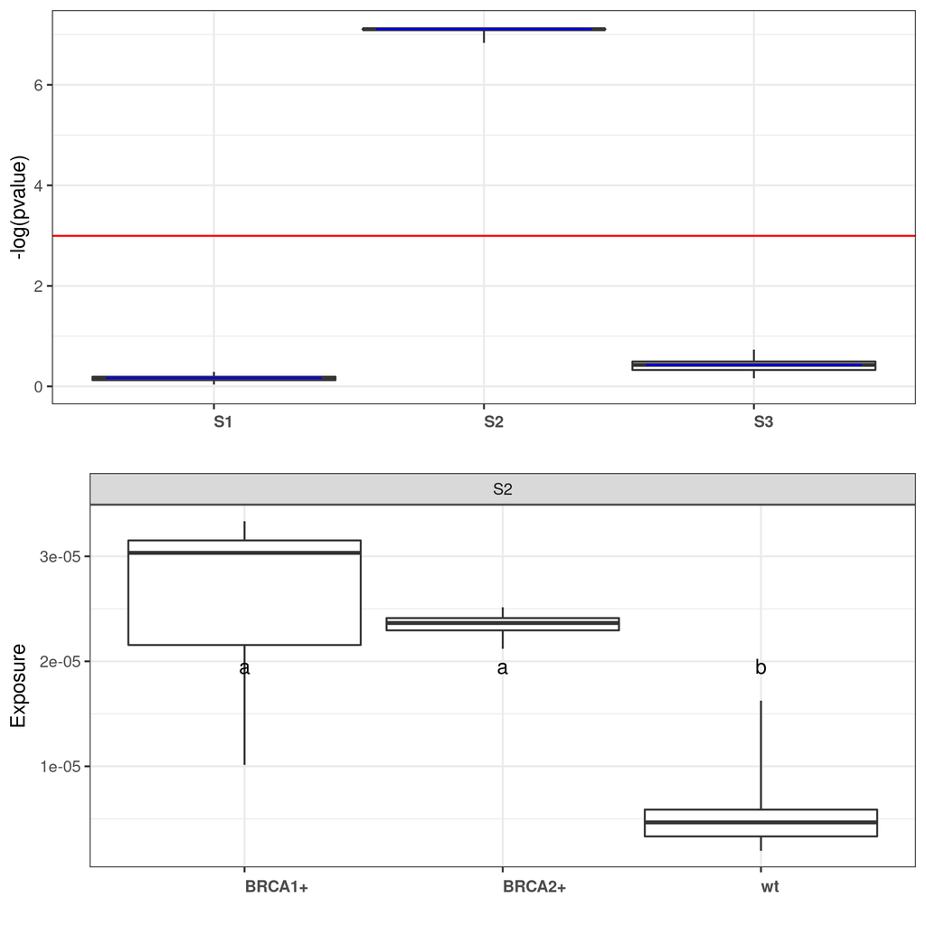

The `Pvquant` vector holds the pvalues quantile of the test for each signature (by default, the 0.5 quantile, i.e. the median). The logarithms of those are considered the Differential Exposure Scores (DES). Signatures with `Pvquant` values below the cutoff, 0.05 by default, are considered as differentially exposed.

```r
# pvalues
diff_exposure$Pvquant
```

```
## [1] 0.8459322399 0.0008188777 0.6514390575
```

The `MostExposed` vector contains the name of the group where each differentially exposed signature showed the highest levels of activity.

```r
# most exposed group
diff_exposure$MostExposed
```

```
## [1] NA       "BRCA1+" NA
```

### 7.2: Sample Classification

**signeR** can also classify samples based on their exposures to mutational processes. In order to do this, a vector of target labels must be provided to the function ExposureClassify. Samples corresponding to NA values in this vector will be classified according to the similarity of their mutational profiles to the ones of labeled samples. Several classification algorithms are available: k-nearst neighbour (knn), linear vector quantization (lvq), Logistic regressin(logreg), linear discriminant analysis (lda), least absolute shrinkage and selection operator (lasso), naive bayes(nb), support vector machines (svm), random forests (rf) and adaboost (ab). The following example uses the sample labels defined in the DES analysis performed previously.

```r
# note that BRCA_labels [15],[20] and [21] are set to NA
BRCA_labels <- c("wt","BRCA+","BRCA+","BRCA+","BRCA+","BRCA+","BRCA+","wt","wt",
    "wt","wt","BRCA+","wt","BRCA+",NA,"wt","wt","wt","wt",NA,NA)

Class <- ExposureClassify(signatures$SignExposures, labels=BRCA_labels, method="knn")
```

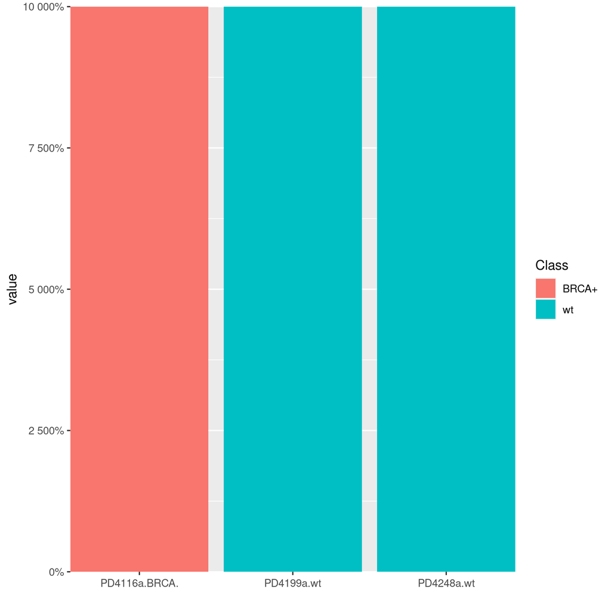

Barplot showing the relative frequencies of assignment of each unlabeled sample to the selected group.

```r
# Final assignments
Class$class
```

```
## PD4116a PD4199a PD4248a
## "BRCA+"    "wt"    "wt"
```

```r
# Relative frequencies of assignment to selected groups
Class$freq
```

```
## PD4116a PD4199a PD4248a
##       1       1       1
```

```r
# All assigment frequencies
Class$allfreqs
```

```
##       PD4116a-BRCA+ PD4199a-wt PD4248a-wt
## BRCA+           100          0          0
## wt                0        100        100
```

### 7.3: Correlation Analysis

When a continuous feature is available for the samples being analysed, **signeR** can evaluate its correlation to exposures to mutational signatures. The following command applies the `cor.test` function to evaluate the correlation of the provided feature and the levels of exposure of each signature:

```r
# feature values, respective to each row of the mutation count matrix.
# The feature simulated below will be correlated with exposures to signature 2.
myFeature <- (10^6)*Median_exp(signatures$SignExposures)[2,] + rnorm(21,0,1)

ExpCorr <- ExposureCorrelation(signatures$SignExposures, feature=myFeature)
```

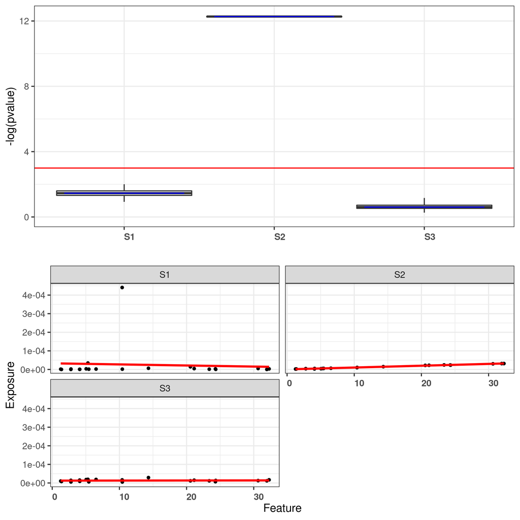

P-values boxplot and scatterplots showing the correlations of exposures and the provided feature.

The output `ExpCorr` will contain a list with two vectors: the estimated correlations of the signatures to the feature and their estimated pvalues.

### 7.4: Linear Regression

A continuous feature may also be modeled by its exposures to mutational signatures. The following command applies the `glm` function to fit a linear model with the provided feature as output of the levels of exposures to mutational signatures:

```r
ExpLM <- ExposureGLM(signatures$SignExposures, feature=myFeature)
```

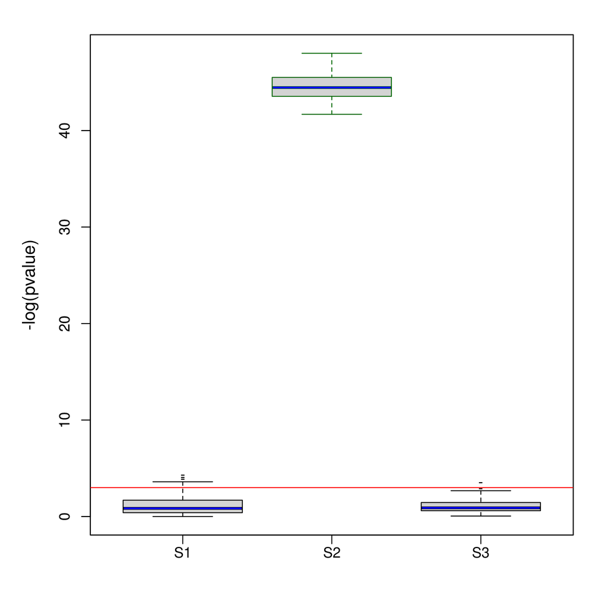

P-values boxplot showing the relevance of exposures in final model of provided feature.